# Assignment 4

## Try to submit as an HTML file

Print your Emory ID below

```python
# Write down your answer here:
print("2585210")
```

```
2585210
```

Import the numpy, matplotlib, and pandas packages

```python
# Write down your answer here:
import numpy as np
import matplotlib.pyplot as plt
import pandas as pd
```

(a) Create a sequence

- Create a value $n = 42$
- Create a list with the values $0,1,\ldots, n$
- Count the length of the list

```python
# Write your own code
N=42
range_list=list(range(0,N))
print(len(range_list))
print(range_list)
```

```
42
[0, 1, 2, 3, 4, 5, 6, 7, 8, 9, 10, 11, 12, 13, 14, 15, 16, 17, 18, 19, 20, 21, 22, 23, 24, 25, 26, 27, 28, 29, 30, 31, 32, 33, 34, 35, 36, 37, 38, 39, 40, 41]
```

(b) Counting True/False statements in a list

- Create list_age = [58, 23, 63, 18, 76, 35, 48, 68]
- Create an empty list "list_eligible_retire"
- Use a for-loop without numbering
  - Determine whether the age is $\ge 65$
  - Store the True/False result in "list_eligible_retire"
- Use "np.sum()" to count how many workers are eligible for retirement

Hint: Use the "append" function.

```python
# Write your own code
list_age=[58,23, 63, 18, 76, 35, 48, 68]
list_eligible_retire=[]
for age in list_age:
    if age>=65:
        list_eligible_retire.append(True)
    else:
        list_eligible_retire.append(False)

print(list_eligible_retire)
print(np.sum(np.array((list_eligible_retire))))
```

```
[False, False, False, False, True, False, False, True]
2
```

(c) Graphs from multiple datasets

- Create a list with the two "DF Open" datasets for 2022, and 2023
- Run a for-loop over each dataset
  - Compute a histogram of "overallScore" for each year
  - Label the title with the name of the dataset

Note: the dataset showcases the data from the 2022 and 2023 crossfit games

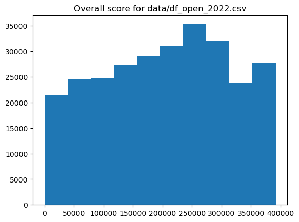

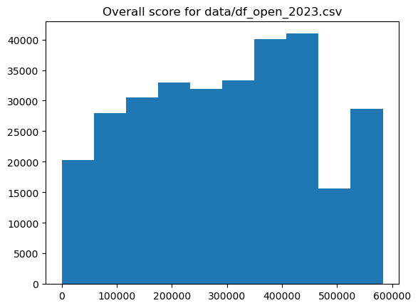

```python
# Note "overallScore" is the final score each candidate achieved

# Hint: Before you write the loop, test your code out by opening an individual dataset
# Once you're sure the code works and you're familiar with the data, run the loop
df_list = ['data/df_open_2022.csv','data/df_open_2023.csv']
for element in df_list:
    df = pd.read_csv(element)
    plt.hist(df['overallScore'])
    plt.title("Overall score for " +element)
    plt.show()
```

For questions (d) and (e), use the following table:

[figure not shown]

(d) Loops with multiple lists

- Create three lists

list_lower = [93, 90, 87, 83, 80, 77, 73, 70, 67, 63, 60, 0]

list_upper = [100, 92, 89, 86, 82, 79, 76, 72, 69, 66, 62, 59]

list_letters = ["A","A-","B+","B","B-","C+","C","C-","D+","D","D-","F"]

- Create a for loop that prints the message:

"If a students gets a grade between .... and ..., their letter grade is ..."

```python
# Hint: Use a for-loop with numbering
# Start the index at zero
# In the body of the loop, extract the elements in each list by the index position
list_lower = [93, 90, 87, 83, 80, 77, 73, 70, 67, 63, 60, 0]

list_upper = [100, 92, 89, 86, 82, 79, 76, 72, 69, 66, 62, 59]

list_letters = ["A","A-","B+","B","B-","C+","C","C-","D+","D","D-","F"]

for element in range(len(list_lower)):
    low = list_lower[element]
    high = list_upper[element]
    grade = list_letters[element]
    print('If a student gets a grade between '+ str(low)+ ' and '+str(high)+ ' their grade is '+str(grade))
```

```
If a student gets a grade between 93 and 100 their grade is A
If a student gets a grade between 90 and 92 their grade is A-
If a student gets a grade between 87 and 89 their grade is B+
If a student gets a grade between 83 and 86 their grade is B
If a student gets a grade between 80 and 82 their grade is B-
If a student gets a grade between 77 and 79 their grade is C+
If a student gets a grade between 73 and 76 their grade is C
If a student gets a grade between 70 and 72 their grade is C-
If a student gets a grade between 67 and 69 their grade is D+
If a student gets a grade between 63 and 66 their grade is D
If a student gets a grade between 60 and 62 their grade is D-
If a student gets a grade between 0 and 59 their grade is F
```

(e) Classification with double loops

- Suppose that 7 students get the following grades:

list_studentgrades = [84, 62, 92, 74, 97, 80, 79]

- Print the following message:

"The student got a numeric grade of .... and their letter grade was ..."

```python
for grade in list_studentgrades:
    for i in range(len(list_letters)):
        lower = list_lower[i]
        upper = list_upper[i]
        letter = list_letters[i]
        if lower <= grade <= upper:
            message = f"The student got a numeric grade of {grade} and their letter grade was {letter}."
            print(message)
            break
```

```
The student got a numeric grade of 84 and their letter grade was B.
The student got a numeric grade of 62 and their letter grade was D-.
The student got a numeric grade of 92 and their letter grade was A-.
The student got a numeric grade of 74 and their letter grade was C.
The student got a numeric grade of 97 and their letter grade was A.
The student got a numeric grade of 80 and their letter grade was B-.
The student got a numeric grade of 79 and their letter grade was C+.
```